# Clustering and classification

## Brief description of the dataset

In this chapter the purpose is to get familiar with clustering and classification. I’m going to use a dataset called **Boston** which contains information collected by the U.S Census Service concerning housing in the area of Boston Mass. The data was originally published by Harrison, D. and Rubinfeld, D.L. “Hedonic prices and the demand for clean air”, J. Environ. Economics & Management, vol.5, 81-102, 1978. You can find some additional information [here](http://www.clemson.edu/economics/faculty/wilson/R-tutorial/analyzing_data.html) and [here](https://archive.ics.uci.edu/ml/machine-learning-databases/housing/).

This dataset is actually already loaded into R thus let’s take a look at some details.

**DATA VARIABLES**

- crim - per capita crime rate by town
- zn - proportion of residential land zoned for lots over 25,000 sq.ft.
- indus - proportion of non-retail business acres per town
- chas - Charles River dummy variable (= 1 if tract bounds river; 0 otherwise)
- nox - nitrogen oxides concentration (parts per 10 million)
- rm - average number of rooms per dwelling
- age - proportion of owner-occupied units built prior to 1940
- dis - weighted mean of distances to five Boston employment centres
- rad - index of accessibility to radial highways
- tax - full-value property-tax rate per $10,000
- ptratio - pupil-teacher ratio by town
- black - 1000(Bk - 0.63)^2 where Bk is the proportion of blacks by town
- lstat - lower status of the population (percent)
- medv - median value of owner-occupied homes in $1000s

**STRUCTURE OFTHE BOSTON DATASET**

From the structure table you can notice that there are 506 observation and 14 variables including 13 continuous variables and 1 binary-valued variable “chas”.

```r
library(MASS)
data("Boston")
str(Boston)
```

```
## 'data.frame':    506 obs. of  14 variables:
##  $ crim   : num  0.00632 0.02731 0.02729 0.03237 0.06905 ...
##  $ zn     : num  18 0 0 0 0 0 12.5 12.5 12.5 12.5 ...
##  $ indus  : num  2.31 7.07 7.07 2.18 2.18 2.18 7.87 7.87 7.87 7.87 ...
##  $ chas   : int  0 0 0 0 0 0 0 0 0 0 ...
##  $ nox    : num  0.538 0.469 0.469 0.458 0.458 0.458 0.524 0.524 0.524 0.524 ...
##  $ rm     : num  6.58 6.42 7.18 7 7.15 ...
##  $ age    : num  65.2 78.9 61.1 45.8 54.2 58.7 66.6 96.1 100 85.9 ...
##  $ dis    : num  4.09 4.97 4.97 6.06 6.06 ...
##  $ rad    : int  1 2 2 3 3 3 5 5 5 5 ...
##  $ tax    : num  296 242 242 222 222 222 311 311 311 311 ...
##  $ ptratio: num  15.3 17.8 17.8 18.7 18.7 18.7 15.2 15.2 15.2 15.2 ...
##  $ black  : num  397 397 393 395 397 ...
##  $ lstat  : num  4.98 9.14 4.03 2.94 5.33 ...
##  $ medv   : num  24 21.6 34.7 33.4 36.2 28.7 22.9 27.1 16.5 18.9 ...
```

## Summaries and graphs

In this section I’m going to explore the distributions of data variables even further. First I show you a summary table which contains the distributions of each variable where the variables are divided into quartiles including the minimum and maximum values.

After this I’ll show you the histograms of these variables excluding chas and black. Chas is a dummy variable concisting the values 1 or 0. The reason for me of dropping black is ethical. Remember that the current dataset is already “long in the tooth”. However, from the histograms you can have a better understanding of the variation of each variable.

At the end of this chapter I’ll explore the correlations between the variables and demonstrate them by means of the the correlation matrix table and the correlation matrix plot.

**SUMMARY TABLE OF DATA VARIABLES**

From the summary table below you can perceive that all of the ditributions varies between very different scales.

```r
summary(Boston)
```

```
##       crim                zn             indus            chas
##  Min.   : 0.00632   Min.   :  0.00   Min.   : 0.46   Min.   :0.00000
##  1st Qu.: 0.08204   1st Qu.:  0.00   1st Qu.: 5.19   1st Qu.:0.00000
##  Median : 0.25651   Median :  0.00   Median : 9.69   Median :0.00000
##  Mean   : 3.61352   Mean   : 11.36   Mean   :11.14   Mean   :0.06917
##  3rd Qu.: 3.67708   3rd Qu.: 12.50   3rd Qu.:18.10   3rd Qu.:0.00000
##  Max.   :88.97620   Max.   :100.00   Max.   :27.74   Max.   :1.00000
##       nox               rm             age              dis
##  Min.   :0.3850   Min.   :3.561   Min.   :  2.90   Min.   : 1.130
##  1st Qu.:0.4490   1st Qu.:5.886   1st Qu.: 45.02   1st Qu.: 2.100
##  Median :0.5380   Median :6.208   Median : 77.50   Median : 3.207
##  Mean   :0.5547   Mean   :6.285   Mean   : 68.57   Mean   : 3.795
##  3rd Qu.:0.6240   3rd Qu.:6.623   3rd Qu.: 94.08   3rd Qu.: 5.188
##  Max.   :0.8710   Max.   :8.780   Max.   :100.00   Max.   :12.127
##       rad              tax           ptratio          black
##  Min.   : 1.000   Min.   :187.0   Min.   :12.60   Min.   :  0.32
##  1st Qu.: 4.000   1st Qu.:279.0   1st Qu.:17.40   1st Qu.:375.38
##  Median : 5.000   Median :330.0   Median :19.05   Median :391.44
##  Mean   : 9.549   Mean   :408.2   Mean   :18.46   Mean   :356.67
##  3rd Qu.:24.000   3rd Qu.:666.0   3rd Qu.:20.20   3rd Qu.:396.23
##  Max.   :24.000   Max.   :711.0   Max.   :22.00   Max.   :396.90
##      lstat            medv
##  Min.   : 1.73   Min.   : 5.00
##  1st Qu.: 6.95   1st Qu.:17.02
##  Median :11.36   Median :21.20
##  Mean   :12.65   Mean   :22.53
##  3rd Qu.:16.95   3rd Qu.:25.00
##  Max.   :37.97   Max.   :50.00
```

**HISTOGRAMS OF CRIM, ZN, INDUS AND NOX**

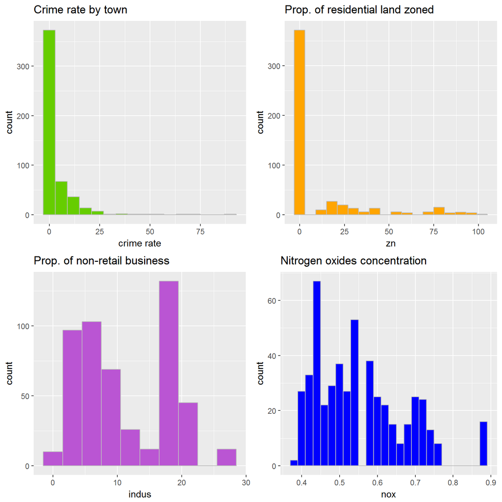

```r
library(ggplot2); library(gridExtra);library(dygraphs)

# INITIALIZING THE PLOTS

# Histogram of crim
hcrim <- qplot(Boston$crim, geom = "histogram", binwidth = 6, main = "Crime rate by town", xlab = "crime rate", col = I("grey"), fill = I("chartreuse3"))

# Histogram of zn
hzn <- qplot(Boston$zn, geom = "histogram", binwidth = 6, main = "Prop. of residential land zoned", xlab = "zn", col = I("grey"), fill = I("orange"))

# Histogram of indus
hindus <- qplot(Boston$indus, geom = "histogram", binwidth = 3, main = "Prop. of non-retail business", xlab = "indus", col = I("grey"), fill = I("mediumorchid"))

hnox <- qplot(Boston$nox, geom = "histogram", binwidth = 0.02, main = "Nitrogen oxides concentration", xlab = "nox", col = I("grey"), fill = I("blue"))


# Combining the plots using the function grid.arrange() [in gridExtra]

# Additional information from (http://www.sthda.com/english/wiki/ggplot2-easy-way-to-mix-multiple-graphs-on-the-same-page-r-software-and-data-visualization)

grid.arrange(hcrim, hzn, hindus, hnox, ncol=2, nrow =2)
```

**HISTOGRAMS OF RM, AGE, DIS AND RAD**

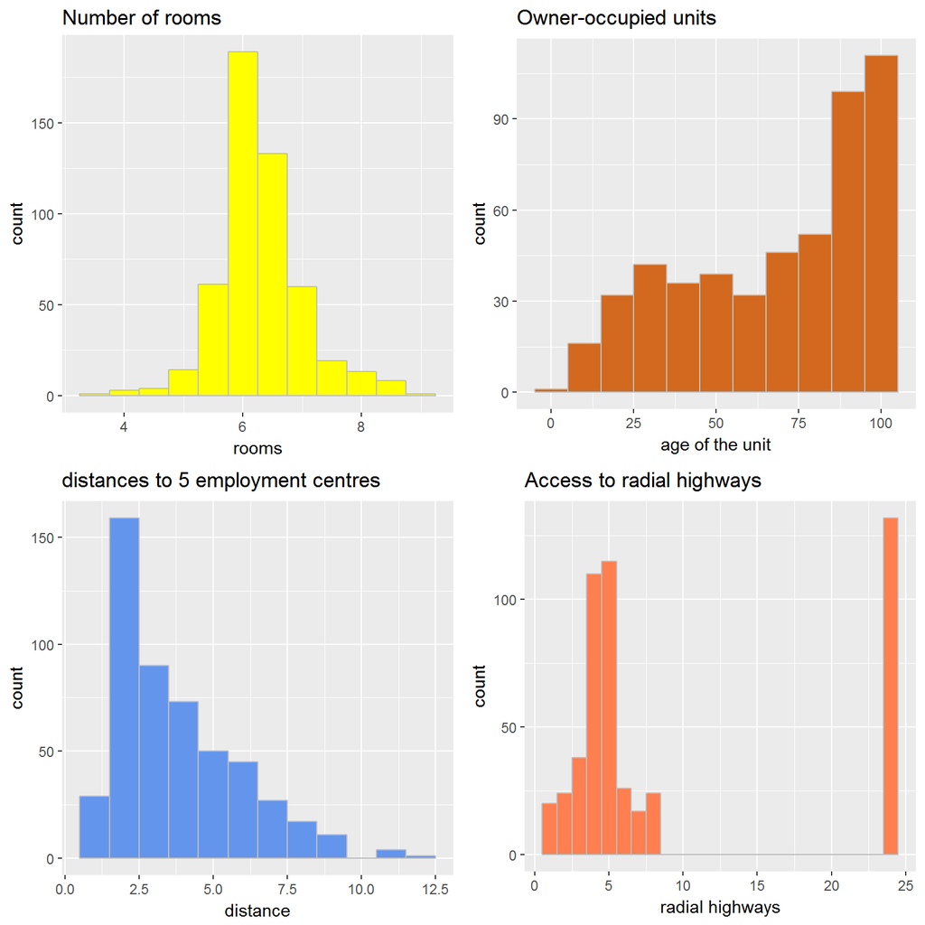

```r
library(ggplot2); library(gridExtra); library(dygraphs)

# INITIALIZING THE PLOTS

hrm <- qplot(Boston$rm, geom = "histogram", binwidth = 0.5, main = "Number of rooms", xlab = "rooms", col = I("grey"), fill = I("yellow"))

hage <- qplot(Boston$age, geom = "histogram", binwidth = 10, main = "Owner-occupied units", xlab = "age of the unit", col = I("grey"), fill = I("chocolate"))

hdis <- qplot(Boston$dis, geom = "histogram", binwidth = 1, main = "distances to 5 employment centres", xlab = "distance", col = I("grey"), fill = I("cornflowerblue"))

hrad <- qplot(Boston$rad, geom = "histogram", binwidth = 1, main = "Access to radial highways", xlab = "radial highways", col = I("grey"), fill = I("coral"))

# Combining the plots using the function grid.arrange() [in gridExtra]

grid.arrange(hrm, hage, hdis, hrad, ncol=2, nrow =2)
```

**HISTOGRAMS OF TAX, PTRATIO, LSTAT AND MEDV**

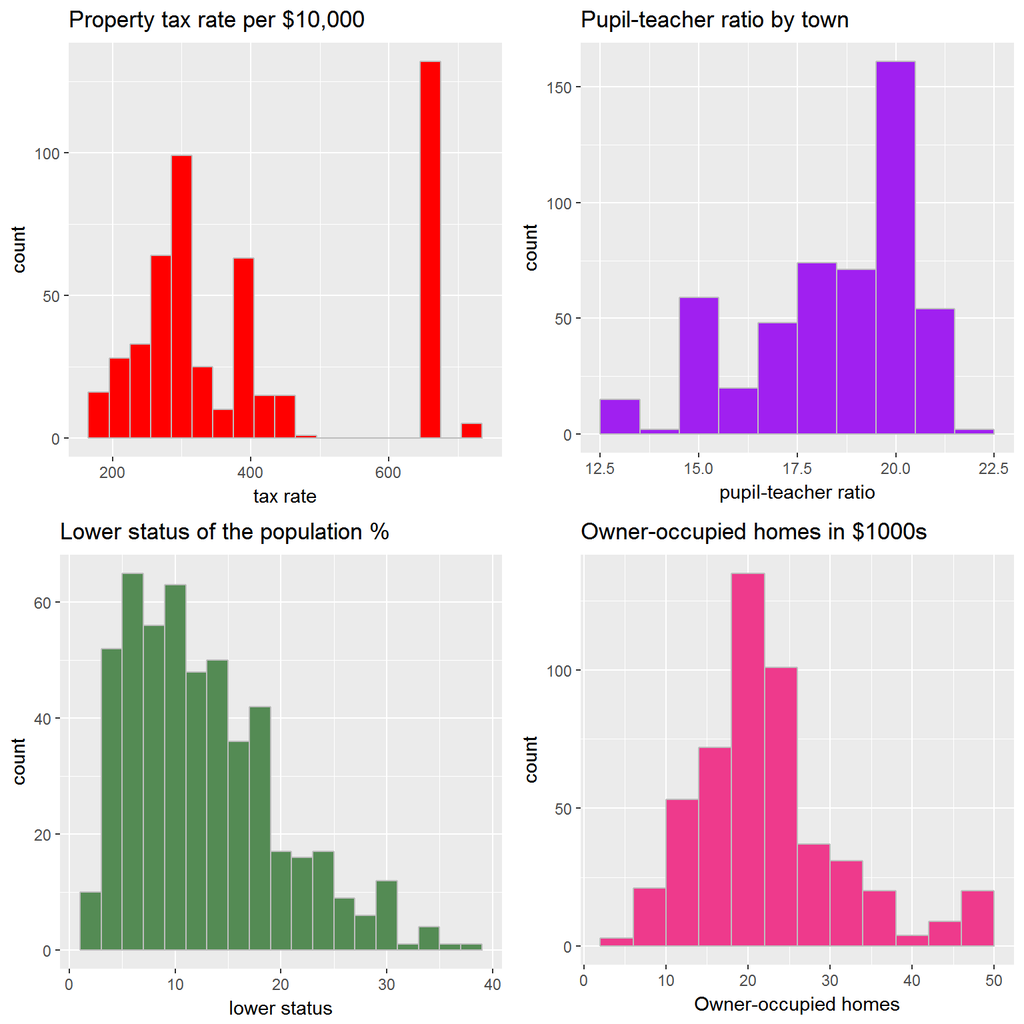

```r
library(ggplot2); library(gridExtra); library(dygraphs)

# INITIALIZING THE PLOTS

htax <- qplot(Boston$tax, geom = "histogram", binwidth = 30, main = "Property tax rate per $10,000", xlab = "tax rate", col = I("grey"), fill = I("red"))

hptratio <- qplot(Boston$ptratio, geom = "histogram", binwidth = 1, main = "Pupil-teacher ratio by town", xlab = "pupil-teacher ratio", col = I("grey"), fill = I("purple"))

hlstat <- qplot(Boston$lstat, geom = "histogram", binwidth = 2, main = "Lower status of the population %", xlab = "lower status", col = I("grey"), fill = I("palegreen4"))

hmedv <- qplot(Boston$medv, geom = "histogram", binwidth = 4, main = "Owner-occupied homes in $1000s", xlab = "Owner-occupied homes", col = I("grey"), fill = I("violetred2"))

# Combining the plots using the function grid.arrange() [in gridExtra]

grid.arrange(htax, hptratio, hlstat, hmedv, ncol=2, nrow =2)
```

**CORRELATION MATRIX BETWEEN DATA VARIABLES**

```r
library(tidyverse)
cor_matrix <- cor(Boston) %>% round(digits = 2)
cor_matrix
```

```
##          crim    zn indus  chas   nox    rm   age   dis   rad   tax
## crim     1.00 -0.20  0.41 -0.06  0.42 -0.22  0.35 -0.38  0.63  0.58
## zn      -0.20  1.00 -0.53 -0.04 -0.52  0.31 -0.57  0.66 -0.31 -0.31
## indus    0.41 -0.53  1.00  0.06  0.76 -0.39  0.64 -0.71  0.60  0.72
## chas    -0.06 -0.04  0.06  1.00  0.09  0.09  0.09 -0.10 -0.01 -0.04
## nox      0.42 -0.52  0.76  0.09  1.00 -0.30  0.73 -0.77  0.61  0.67
## rm      -0.22  0.31 -0.39  0.09 -0.30  1.00 -0.24  0.21 -0.21 -0.29
## age      0.35 -0.57  0.64  0.09  0.73 -0.24  1.00 -0.75  0.46  0.51
## dis     -0.38  0.66 -0.71 -0.10 -0.77  0.21 -0.75  1.00 -0.49 -0.53
## rad      0.63 -0.31  0.60 -0.01  0.61 -0.21  0.46 -0.49  1.00  0.91
## tax      0.58 -0.31  0.72 -0.04  0.67 -0.29  0.51 -0.53  0.91  1.00
## ptratio  0.29 -0.39  0.38 -0.12  0.19 -0.36  0.26 -0.23  0.46  0.46
## black   -0.39  0.18 -0.36  0.05 -0.38  0.13 -0.27  0.29 -0.44 -0.44
## lstat    0.46 -0.41  0.60 -0.05  0.59 -0.61  0.60 -0.50  0.49  0.54
## medv    -0.39  0.36 -0.48  0.18 -0.43  0.70 -0.38  0.25 -0.38 -0.47
##         ptratio black lstat  medv
## crim       0.29 -0.39  0.46 -0.39
## zn        -0.39  0.18 -0.41  0.36
## indus      0.38 -0.36  0.60 -0.48
## chas      -0.12  0.05 -0.05  0.18
## nox        0.19 -0.38  0.59 -0.43
## rm        -0.36  0.13 -0.61  0.70
## age        0.26 -0.27  0.60 -0.38
## dis       -0.23  0.29 -0.50  0.25
## rad        0.46 -0.44  0.49 -0.38
## tax        0.46 -0.44  0.54 -0.47
## ptratio    1.00 -0.18  0.37 -0.51
## black     -0.18  1.00 -0.37  0.33
## lstat      0.37 -0.37  1.00 -0.74
## medv      -0.51  0.33 -0.74  1.00
```

**PLOTTING THE CORRELATION MATRIX**

I used the corrplot() to better demonstrate the above correlation matrix. You can see this plot below and it is good to know that positive correlations are displayed in blue and negative correlations in red color. Color intensity and the size of the circle are proportional to the correlation coefficients. The legend color shows the correlation coefficients and the corresponding colors. I also added the values of correlations of each pair even though the plot is not so beautiful after this.

Within the next chapters I’m going to concentrate more on crime rates as a target variable thus its also convenient to explore here the relationships between crime rate and other variables. You can see the highest positive correlations are between crime rate and rad as well as crime rate and tax rate. I’m not sure what these are actuallyt telling us. An by this I mean that sometimes variables can correlate without any specific cause - effect impacts. Here the crime rate by town correlates positive with accessibility to radial highways but I can’t figure out any “real” reasons why this is happening. Maybe the criminals do their crimes in towns from where they can get easily away :D :D

And maybe the positive correlation between crime rate and tax rate indicates that there are more crimes in those areas with bigger properties because bigger properties have bigger taxes. Also there might live wealthier people in bigger properties which may be more tempting for example to the thiefs. I’m not sure what kind of crimes the crime rate contains but I think you get my point.

Then there are more moderate negative correlations between crime rate and medv as well as between crime rate and dis. The medv indicates the median value of owner-occupied homes in $1000s and the correlation suggests that the crime rate is higher when the median value of owner-occupied homes is lower and vice versa. I don’t try to interpret this unattached from the bigger picture because there can be several reasons fro this. The dis indicates the weighted mean of distances to five Boston employment centres. Thus the negative correlation tells us that the higher the crime rate, the lower the mean distance and vice versa. This may be logical in the way that there can more crimes near these centres (shorter distance) comparing the more rural areas (greater distance).

Note that under the corrplot you can find a pair (scatter plot) matrix which illustrates also the relationships between different variables.

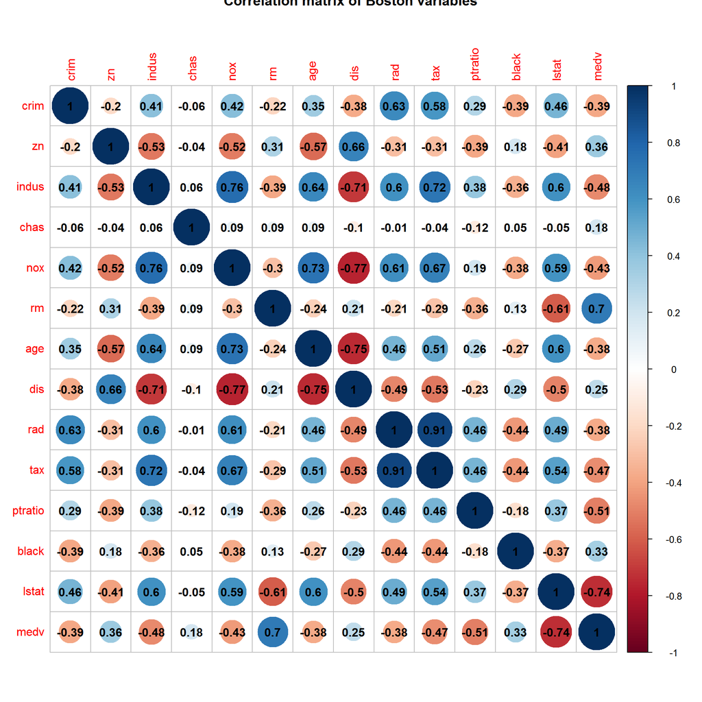

```r
library(corrplot); library(dygraphs)
corrplot(cor_matrix, method = "circle", main = "Correlation matrix of Boston variables", tl.cex = 1, addCoef.col = "black")
```

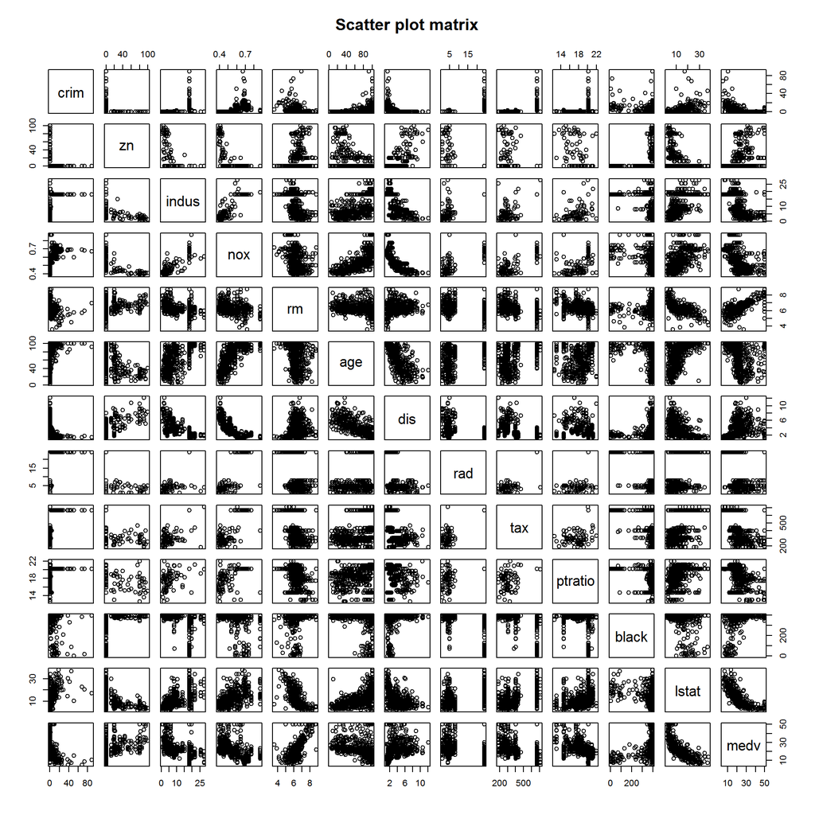

```r
library(ggplot2)
library(GGally)
pairs(Boston [-4], main = "Scatter plot matrix")
```

## Scaling the Boston dataset

In this chapter I’m going to scale or standardize the whole dataset.

**SUMMARIES OF THE SCALED DATA**

As you can see from the table below, the distributions of the variables changed after stardardizing the dataset. Now the mean of every variable is zero and the observations varies on both sides of zero. This means that the different distributions are now more comparable for the further purpose.

```r
boston_scaled <- scale(Boston)
summary(boston_scaled)
```

```
##       crim                 zn               indus
##  Min.   :-0.419367   Min.   :-0.48724   Min.   :-1.5563
##  1st Qu.:-0.410563   1st Qu.:-0.48724   1st Qu.:-0.8668
##  Median :-0.390280   Median :-0.48724   Median :-0.2109
##  Mean   : 0.000000   Mean   : 0.00000   Mean   : 0.0000
##  3rd Qu.: 0.007389   3rd Qu.: 0.04872   3rd Qu.: 1.0150
##  Max.   : 9.924110   Max.   : 3.80047   Max.   : 2.4202
##       chas              nox                rm               age
##  Min.   :-0.2723   Min.   :-1.4644   Min.   :-3.8764   Min.   :-2.3331
##  1st Qu.:-0.2723   1st Qu.:-0.9121   1st Qu.:-0.5681   1st Qu.:-0.8366
##  Median :-0.2723   Median :-0.1441   Median :-0.1084   Median : 0.3171
##  Mean   : 0.0000   Mean   : 0.0000   Mean   : 0.0000   Mean   : 0.0000
##  3rd Qu.:-0.2723   3rd Qu.: 0.5981   3rd Qu.: 0.4823   3rd Qu.: 0.9059
##  Max.   : 3.6648   Max.   : 2.7296   Max.   : 3.5515   Max.   : 1.1164
##       dis               rad               tax             ptratio
##  Min.   :-1.2658   Min.   :-0.9819   Min.   :-1.3127   Min.   :-2.7047
##  1st Qu.:-0.8049   1st Qu.:-0.6373   1st Qu.:-0.7668   1st Qu.:-0.4876
##  Median :-0.2790   Median :-0.5225   Median :-0.4642   Median : 0.2746
##  Mean   : 0.0000   Mean   : 0.0000   Mean   : 0.0000   Mean   : 0.0000
##  3rd Qu.: 0.6617   3rd Qu.: 1.6596   3rd Qu.: 1.5294   3rd Qu.: 0.8058
##  Max.   : 3.9566   Max.   : 1.6596   Max.   : 1.7964   Max.   : 1.6372
##      black             lstat              medv
##  Min.   :-3.9033   Min.   :-1.5296   Min.   :-1.9063
##  1st Qu.: 0.2049   1st Qu.:-0.7986   1st Qu.:-0.5989
##  Median : 0.3808   Median :-0.1811   Median :-0.1449
##  Mean   : 0.0000   Mean   : 0.0000   Mean   : 0.0000
##  3rd Qu.: 0.4332   3rd Qu.: 0.6024   3rd Qu.: 0.2683
##  Max.   : 0.4406   Max.   : 3.5453   Max.   : 2.9865
```

**CATEGORIZING THE CRIME RATE**

There are a lot of technicalities in this part thus I decided to describe the steps inside the r code chunks. the main point here is to create a new categorical variable based on the scaled crime rate and split it on to 4 categories by means of the its quantiles labelled as “low”, “med_low”, “med_high” and “high”. After this I remove the “original” scaled crime rate from the dataset.

```r
# Converting the scaled data into a data frame
boston_scaled <- as.data.frame(boston_scaled)

scaled_crim <- boston_scaled$crim

# Using the quantiles as the break points in the categorical variable of scaled_crim
bins <- quantile(scaled_crim)
bins
```

```
##           0%          25%          50%          75%         100%
## -0.419366929 -0.410563278 -0.390280295  0.007389247  9.924109610
```

```r
# Creating a categorical variable "crime"
boston_scaled$crime <- cut(scaled_crim, breaks = bins, include.lowest = TRUE, labels = c("low", "med_low", "med_high", "high"))

crime <- boston_scaled$crime
table(crime)
```

```
## crime
##      low  med_low med_high     high
##      127      126      126      127
```

```r
# Verifying the content
colnames(boston_scaled)
```

```
##  [1] "crim"    "zn"      "indus"   "chas"    "nox"     "rm"      "age"
##  [8] "dis"     "rad"     "tax"     "ptratio" "black"   "lstat"   "medv"
## [15] "crime"
```

```r
class(boston_scaled)
```

```
## [1] "data.frame"
```

```r
# Dropping the old crime rate from the dataset
library(dplyr)
boston_scaled <- dplyr::select(boston_scaled, -crim)

# Veryfying the content
colnames(boston_scaled)
```

```
##  [1] "zn"      "indus"   "chas"    "nox"     "rm"      "age"     "dis"
##  [8] "rad"     "tax"     "ptratio" "black"   "lstat"   "medv"    "crime"
```

```r
summary(boston_scaled)
```

```
##        zn               indus              chas              nox
##  Min.   :-0.48724   Min.   :-1.5563   Min.   :-0.2723   Min.   :-1.4644
##  1st Qu.:-0.48724   1st Qu.:-0.8668   1st Qu.:-0.2723   1st Qu.:-0.9121
##  Median :-0.48724   Median :-0.2109   Median :-0.2723   Median :-0.1441
##  Mean   : 0.00000   Mean   : 0.0000   Mean   : 0.0000   Mean   : 0.0000
##  3rd Qu.: 0.04872   3rd Qu.: 1.0150   3rd Qu.:-0.2723   3rd Qu.: 0.5981
##  Max.   : 3.80047   Max.   : 2.4202   Max.   : 3.6648   Max.   : 2.7296
##        rm               age               dis               rad
##  Min.   :-3.8764   Min.   :-2.3331   Min.   :-1.2658   Min.   :-0.9819
##  1st Qu.:-0.5681   1st Qu.:-0.8366   1st Qu.:-0.8049   1st Qu.:-0.6373
##  Median :-0.1084   Median : 0.3171   Median :-0.2790   Median :-0.5225
##  Mean   : 0.0000   Mean   : 0.0000   Mean   : 0.0000   Mean   : 0.0000
##  3rd Qu.: 0.4823   3rd Qu.: 0.9059   3rd Qu.: 0.6617   3rd Qu.: 1.6596
##  Max.   : 3.5515   Max.   : 1.1164   Max.   : 3.9566   Max.   : 1.6596
##       tax             ptratio            black             lstat
##  Min.   :-1.3127   Min.   :-2.7047   Min.   :-3.9033   Min.   :-1.5296
##  1st Qu.:-0.7668   1st Qu.:-0.4876   1st Qu.: 0.2049   1st Qu.:-0.7986
##  Median :-0.4642   Median : 0.2746   Median : 0.3808   Median :-0.1811
##  Mean   : 0.0000   Mean   : 0.0000   Mean   : 0.0000   Mean   : 0.0000
##  3rd Qu.: 1.5294   3rd Qu.: 0.8058   3rd Qu.: 0.4332   3rd Qu.: 0.6024
##  Max.   : 1.7964   Max.   : 1.6372   Max.   : 0.4406   Max.   : 3.5453
##       medv              crime
##  Min.   :-1.9063   low     :127
##  1st Qu.:-0.5989   med_low :126
##  Median :-0.1449   med_high:126
##  Mean   : 0.0000   high    :127
##  3rd Qu.: 0.2683
##  Max.   : 2.9865
```

**CREATING THE TRAIN AND TEST SETS**

```r
# Choosing randomly 80 % of the row
n <- nrow(boston_scaled)
ind <- sample(n, size = n * 0.8)

# Creating train and test sets
train <- boston_scaled[ind,]
test <- boston_scaled[-ind,]

# Inspecting the content
str(train)
```

```
## 'data.frame':    404 obs. of  14 variables:
##  $ zn     : num  -0.487 -0.487 -0.487 -0.487 -0.487 ...
##  $ indus  : num  -0.867 1.231 -1.306 1.015 1.015 ...
##  $ chas   : num  -0.272 -0.272 -0.272 -0.272 -0.272 ...
##  $ nox    : num  -0.343 0.434 -0.834 0.365 1.254 ...
##  $ rm     : num  0.0446 1.7141 0.2069 -1.6078 -1.7771 ...
##  $ age    : num  -1.083 0.79 -0.351 1.116 1.01 ...
##  $ dis    : num  1.265 -0.866 1.077 -1.047 -0.962 ...
##  $ rad    : num  -0.522 -0.522 -0.752 1.66 1.66 ...
##  $ tax    : num  -1.0932 -0.0311 -1.105 1.5294 1.5294 ...
##  $ ptratio: num  0.806 -1.735 0.113 0.806 0.806 ...
##  $ black  : num  0.362 0.194 0.41 -1.596 0.441 ...
##  $ lstat  : num  -0.976 -1.53 -1.042 1.04 1.824 ...
##  $ medv   : num  -0.0362 2.9865 0.6706 -0.6777 -1.3953 ...
##  $ crime  : Factor w/ 4 levels "low","med_low",..: 1 3 1 4 4 4 3 1 2 3 ...
```

```r
str(test)
```

```
## 'data.frame':    102 obs. of  14 variables:
##  $ zn     : num  -0.487 -0.487 -0.487 -0.487 -0.487 ...
##  $ indus  : num  -0.593 -0.437 -0.437 -0.437 -0.437 ...
##  $ chas   : num  -0.272 -0.272 -0.272 -0.272 -0.272 ...
##  $ nox    : num  -0.74 -0.144 -0.144 -0.144 -0.144 ...
##  $ rm     : num  0.194 -0.498 -0.419 -0.338 -0.814 ...
##  $ age    : num  0.367 -1.395 0.466 0.719 0.907 ...
##  $ dis    : num  0.557 0.334 0.22 0.313 0.208 ...
##  $ rad    : num  -0.867 -0.637 -0.637 -0.637 -0.637 ...
##  $ tax    : num  -0.986 -0.601 -0.601 -0.601 -0.601 ...
##  $ ptratio: num  -0.303 1.175 1.175 1.175 1.175 ...
##  $ black  : num  0.4406 0.3305 0.3294 -0.5509 0.0383 ...
##  $ lstat  : num  -0.492 -0.85 0.282 0.648 1.393 ...
##  $ medv   : num  -0.1014 0.0617 -0.5472 -0.8408 -1.0691 ...
##  $ crime  : Factor w/ 4 levels "low","med_low",..: 1 3 3 3 3 2 2 2 2 2 ...
```

```r
colnames(train)
```

```
##  [1] "zn"      "indus"   "chas"    "nox"     "rm"      "age"     "dis"
##  [8] "rad"     "tax"     "ptratio" "black"   "lstat"   "medv"    "crime"
```

```r
colnames(test)
```

```
##  [1] "zn"      "indus"   "chas"    "nox"     "rm"      "age"     "dis"
##  [8] "rad"     "tax"     "ptratio" "black"   "lstat"   "medv"    "crime"
```

## Linear Discriminant Analysis, LDA

Linear discriminant analysis is a classification technique and its preferred over Logistic regression if the target variable has more than two classes. LDA has some assumption about the data and one of these is that the input variables are normally distributed. It also assumes that each attribute has the same variance [Reference](http://machinelearningmastery.com/linear-discriminant-analysis-for-machine-learning/).

Note that the data was standardized earlier in terms of the latter assumption.

**FITTING THE LINEAR DISCRIMINANT ANALYSIS**

LDA defines as many “discriminant functions” as the number of categories of the outcome minus one. I have four categories thus the LDA output shows three functions under the headline “Proportion of trace”. These functions are ordered by the amount of variance that they explain.

```r
library(MASS)
lda.fit <- lda(crime~., data = train)
lda.fit
```

```
## Call:
## lda(crime ~ ., data = train)
##
## Prior probabilities of groups:
##       low   med_low  med_high      high
## 0.2549505 0.2500000 0.2574257 0.2376238
##
## Group means:
##                  zn      indus        chas        nox          rm
## low       0.8198881 -0.9255209 -0.08120770 -0.8481233  0.43994541
## med_low  -0.1032563 -0.2934997  0.03952046 -0.5565190 -0.13653441
## med_high -0.4031350  0.1841756  0.06838153  0.3085742  0.06856267
## high     -0.4872402  1.0149946 -0.02626030  1.1007723 -0.47898153
##                 age        dis        rad        tax     ptratio
## low      -0.8345075  0.8172010 -0.6997720 -0.7401456 -0.41939198
## med_low  -0.2821509  0.3521532 -0.5452263 -0.4683842 -0.08281778
## med_high  0.4275724 -0.3652077 -0.4253064 -0.3179318 -0.23750595
## high      0.8456194 -0.8807881  1.6596029  1.5294129  0.80577843
##               black       lstat         medv
## low       0.3764368 -0.75104484  0.533220765
## med_low   0.3247960 -0.10620407  0.004291667
## med_high  0.1162032  0.01027565  0.178973709
## high     -0.8769349  0.94959320 -0.717333369
##
## Coefficients of linear discriminants:
##                 LD1         LD2        LD3
## zn       0.16687182  0.64727149 -0.9006831
## indus    0.03456623 -0.49091304  0.3839777
## chas     0.02374506  0.00674301  0.1459373
## nox      0.38378301 -0.71191892 -1.4588855
## rm       0.03872628 -0.05987003 -0.1535029
## age      0.24529670 -0.37939674 -0.0189298
## dis     -0.11627513 -0.31464875  0.2510376
## rad      3.63039406  0.83122762  0.0313022
## tax      0.02251815  0.21904774  0.5385015
## ptratio  0.20373941  0.02651081 -0.3025442
## black   -0.15781103  0.01101363  0.1442814
## lstat    0.17350110 -0.27300415  0.3056692
## medv     0.05555340 -0.43346219 -0.2505721
##
## Proportion of trace:
##    LD1    LD2    LD3
## 0.9617 0.0293 0.0090
```

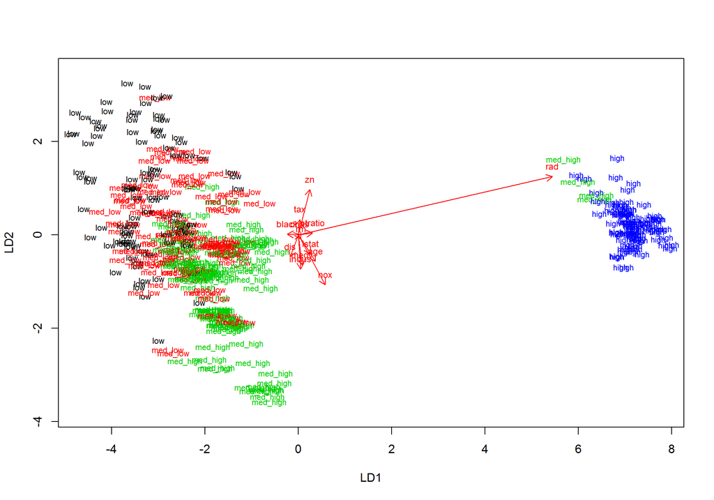

```r
# Creating a numeric vector of the train sets crime classes for plotting purposes
classes <- as.numeric(train$crime)

# the function for lda biplot arrows
lda.arrows <- function(x, myscale = 1, arrow_heads = 0.1, color = "red", tex = 0.75, choices = c(1,2)){
  heads <- coef(x)
  arrows(x0 = 0, y0 = 0,
         x1 = myscale * heads[,choices[1]],
         y1 = myscale * heads[,choices[2]], col=color, length = arrow_heads)
  text(myscale * heads[,choices], labels = row.names(heads),
       cex = tex, col=color, pos=3)
}

# plotting the lda results
plot(lda.fit, dimen = 2, col = classes, pch = classes)
lda.arrows(lda.fit, myscale = 1.5)
```

## Predicting the classes with the Linear Discriminant Analysis, LDA

LDA makes predictions by estimating the probability that a new set of inputs belongs to each class. The class that gets the highest probability is the output class and a prediction is made [Reference](http://machinelearningmastery.com/linear-discriminant-analysis-for-machine-learning/).

First I’m going to save the four crime classes from the test set to “correct_classes” and then I remove the variable from test set, so that I can use the categorized crime as a target variable in LDA prediction when predicting the test data.

**SAVING THE CRIME CATEGORIES**

```r
# Saving the crime classes from the test data into correct_classes
correct_classes <- test$crime

# Removing crime from the test set
library(dplyr)
test <- dplyr::select(test, -crime)

# Veryfying the content of test and correct_classes
str(test)
```

```
## 'data.frame':    102 obs. of  13 variables:
##  $ zn     : num  -0.487 -0.487 -0.487 -0.487 -0.487 ...
##  $ indus  : num  -0.593 -0.437 -0.437 -0.437 -0.437 ...
##  $ chas   : num  -0.272 -0.272 -0.272 -0.272 -0.272 ...
##  $ nox    : num  -0.74 -0.144 -0.144 -0.144 -0.144 ...
##  $ rm     : num  0.194 -0.498 -0.419 -0.338 -0.814 ...
##  $ age    : num  0.367 -1.395 0.466 0.719 0.907 ...
##  $ dis    : num  0.557 0.334 0.22 0.313 0.208 ...
##  $ rad    : num  -0.867 -0.637 -0.637 -0.637 -0.637 ...
##  $ tax    : num  -0.986 -0.601 -0.601 -0.601 -0.601 ...
##  $ ptratio: num  -0.303 1.175 1.175 1.175 1.175 ...
##  $ black  : num  0.4406 0.3305 0.3294 -0.5509 0.0383 ...
##  $ lstat  : num  -0.492 -0.85 0.282 0.648 1.393 ...
##  $ medv   : num  -0.1014 0.0617 -0.5472 -0.8408 -1.0691 ...
```

```r
colnames(test)
```

```
##  [1] "zn"      "indus"   "chas"    "nox"     "rm"      "age"     "dis"
##  [8] "rad"     "tax"     "ptratio" "black"   "lstat"   "medv"
```

```r
str(correct_classes)
```

```
##  Factor w/ 4 levels "low","med_low",..: 1 3 3 3 3 2 2 2 2 2 ...
```

```r
summary(test)
```

```
##        zn              indus               chas
##  Min.   :-0.4872   Min.   :-1.55630   Min.   :-0.272329
##  1st Qu.:-0.4872   1st Qu.:-0.89526   1st Qu.:-0.272329
##  Median :-0.4872   Median :-0.29325   Median :-0.272329
##  Mean   : 0.1439   Mean   : 0.08214   Mean   :-0.002136
##  3rd Qu.: 0.3703   3rd Qu.: 1.01499   3rd Qu.:-0.272329
##  Max.   : 3.5861   Max.   : 2.42017   Max.   : 3.664771
##       nox                 rm                age
##  Min.   :-1.42991   Min.   :-1.87105   Min.   :-2.2052
##  1st Qu.:-0.92076   1st Qu.:-0.45990   1st Qu.:-1.1031
##  Median :-0.14407   Median :-0.07705   Median : 0.2620
##  Mean   : 0.05686   Mean   : 0.07184   Mean   :-0.1098
##  3rd Qu.: 0.79657   3rd Qu.: 0.49154   3rd Qu.: 0.9121
##  Max.   : 2.72965   Max.   : 3.55153   Max.   : 1.1164
##       dis                rad               tax
##  Min.   :-1.19192   Min.   :-0.9819   Min.   :-1.30676
##  1st Qu.:-0.86501   1st Qu.:-0.6373   1st Qu.:-0.77572
##  Median :-0.20131   Median :-0.5225   Median :-0.14381
##  Mean   : 0.02743   Mean   : 0.1182   Mean   : 0.09591
##  3rd Qu.: 0.74400   3rd Qu.: 1.6596   3rd Qu.: 1.52941
##  Max.   : 2.57645   Max.   : 1.6596   Max.   : 1.79642
##     ptratio             black              lstat
##  Min.   :-2.70470   Min.   :-3.86686   Min.   :-1.50301
##  1st Qu.:-0.67232   1st Qu.: 0.15051   1st Qu.:-0.82034
##  Median : 0.34387   Median : 0.37369   Median :-0.12086
##  Mean   :-0.01071   Mean   : 0.00513   Mean   :-0.04064
##  3rd Qu.: 0.80578   3rd Qu.: 0.42898   3rd Qu.: 0.55446
##  Max.   : 1.26768   Max.   : 0.44062   Max.   : 2.70785
##       medv
##  Min.   :-1.76499
##  1st Qu.:-0.61789
##  Median :-0.14492
##  Mean   :-0.05004
##  3rd Qu.: 0.23020
##  Max.   : 2.98650
```

**PREDICTING CLASSES WITH TEST DATA**

In this part I’m going to predict the classes with the test data. In addition to our exercises in DataCamp I used the actual command of confusionMatrix() to illustrate the results more clearly. And because of this the table of predicted values comes actually twice. I kept the first table because I wanted to be sure that I manged to code the confusion matrix correctly.

From the confusion matrix we can see that the estimated accuracy on the final model is 73.5%. You can see the same result also from the table where the correct classes are against the predicted classes. And if you like you can count the accuracy % by hand: sum of correctly predicted values divided with the total amount of values.

```r
# Predicting classes with the test data
lda.pred <- predict(lda.fit, newdata = test)
lda.pred$class
```

```
##   [1] med_low  low      med_low  med_high med_high med_low  low
##   [8] low      med_low  med_low  med_low  low      med_low  med_low
##  [15] low      med_low  med_low  low      med_low  low      low
##  [22] med_high med_high med_low  med_low  med_high med_high med_high
##  [29] med_high med_high med_high med_high med_high med_high med_high
##  [36] med_high med_high low      low      low      low      low
##  [43] low      med_low  med_low  low      med_low  low      low
##  [50] med_high med_high med_high med_high low      low      low
##  [57] low      low      low      low      low      med_low  med_low
##  [64] med_low  med_low  med_low  low      low      high     high
##  [71] high     high     high     high     high     high     high
##  [78] high     high     high     high     high     high     high
##  [85] high     high     high     high     high     high     high
##  [92] high     high     high     high     high     high     high
##  [99] high     high     med_low  med_high
## Levels: low med_low med_high high
```

```r
# Cross tabulating the result
table1 <- table(correct = correct_classes, predicted = lda.pred$class)
table1
```

```
##           predicted
## correct    low med_low med_high high
##   low       18       5        1    0
##   med_low    7      13        5    0
##   med_high   2       4       14    2
##   high       0       0        1   30
```

```r
# Some of the packages can be irrelevant. Different sites proposed different packages and then R noted to require some other packages
library(caret); library(lattice); library(mlbench); library(e1071)
confusionMatrix(correct_classes, lda.pred$class)
```

```
## Confusion Matrix and Statistics
##
##           Reference
## Prediction low med_low med_high high
##   low       18       5        1    0
##   med_low    7      13        5    0
##   med_high   2       4       14    2
##   high       0       0        1   30
##
## Overall Statistics
##
##                Accuracy : 0.7353
##                  95% CI : (0.6387, 0.8178)
##     No Information Rate : 0.3137
##     P-Value [Acc > NIR] : < 2.2e-16
##
##                   Kappa : 0.6447
##  Mcnemar's Test P-Value : NA
##
## Statistics by Class:
##
##                      Class: low Class: med_low Class: med_high Class: high
## Sensitivity              0.6667         0.5909          0.6667      0.9375
## Specificity              0.9200         0.8500          0.9012      0.9857
## Pos Pred Value           0.7500         0.5200          0.6364      0.9677
## Neg Pred Value           0.8846         0.8831          0.9125      0.9718
## Prevalence               0.2647         0.2157          0.2059      0.3137
## Detection Rate           0.1765         0.1275          0.1373      0.2941
## Detection Prevalence     0.2353         0.2451          0.2157      0.3039
## Balanced Accuracy        0.7933         0.7205          0.7840      0.9616
```

## Clustering

Clustering refers to a very broad set of techniques for finding subgroups, or clusters, in a dataset. When we cluster the observations of a dataset, we seek to partition them into distinct groups so that the observations within each group are quite similar to each other, while observations in different groups are quite different from each other.

In this chapter I’m going to reload the Boston dataset for the clustering purposes. First I’m going to scale the variables to get comparable distances between the observations. After this I’m going to run the k-means algorithm and investigate the optimal number of clusters.

K-means clustering is an unsupervised learning algorithm which means that there is no outcome to be predicted but instead tries to find patterns in the data.

**RELOADING THE BOSTON DATASET**

```r
reboston <- Boston
str(reboston)
```

```
## 'data.frame':    506 obs. of  14 variables:
##  $ crim   : num  0.00632 0.02731 0.02729 0.03237 0.06905 ...
##  $ zn     : num  18 0 0 0 0 0 12.5 12.5 12.5 12.5 ...
##  $ indus  : num  2.31 7.07 7.07 2.18 2.18 2.18 7.87 7.87 7.87 7.87 ...
##  $ chas   : int  0 0 0 0 0 0 0 0 0 0 ...
##  $ nox    : num  0.538 0.469 0.469 0.458 0.458 0.458 0.524 0.524 0.524 0.524 ...
##  $ rm     : num  6.58 6.42 7.18 7 7.15 ...
##  $ age    : num  65.2 78.9 61.1 45.8 54.2 58.7 66.6 96.1 100 85.9 ...
##  $ dis    : num  4.09 4.97 4.97 6.06 6.06 ...
##  $ rad    : int  1 2 2 3 3 3 5 5 5 5 ...
##  $ tax    : num  296 242 242 222 222 222 311 311 311 311 ...
##  $ ptratio: num  15.3 17.8 17.8 18.7 18.7 18.7 15.2 15.2 15.2 15.2 ...
##  $ black  : num  397 397 393 395 397 ...
##  $ lstat  : num  4.98 9.14 4.03 2.94 5.33 ...
##  $ medv   : num  24 21.6 34.7 33.4 36.2 28.7 22.9 27.1 16.5 18.9 ...
```

**SUMMARY OF NOT SCALED BOSTON DATASET**

```r
summary(reboston)
```

```
##       crim                zn             indus            chas
##  Min.   : 0.00632   Min.   :  0.00   Min.   : 0.46   Min.   :0.00000
##  1st Qu.: 0.08204   1st Qu.:  0.00   1st Qu.: 5.19   1st Qu.:0.00000
##  Median : 0.25651   Median :  0.00   Median : 9.69   Median :0.00000
##  Mean   : 3.61352   Mean   : 11.36   Mean   :11.14   Mean   :0.06917
##  3rd Qu.: 3.67708   3rd Qu.: 12.50   3rd Qu.:18.10   3rd Qu.:0.00000
##  Max.   :88.97620   Max.   :100.00   Max.   :27.74   Max.   :1.00000
##       nox               rm             age              dis
##  Min.   :0.3850   Min.   :3.561   Min.   :  2.90   Min.   : 1.130
##  1st Qu.:0.4490   1st Qu.:5.886   1st Qu.: 45.02   1st Qu.: 2.100
##  Median :0.5380   Median :6.208   Median : 77.50   Median : 3.207
##  Mean   :0.5547   Mean   :6.285   Mean   : 68.57   Mean   : 3.795
##  3rd Qu.:0.6240   3rd Qu.:6.623   3rd Qu.: 94.08   3rd Qu.: 5.188
##  Max.   :0.8710   Max.   :8.780   Max.   :100.00   Max.   :12.127
##       rad              tax           ptratio          black
##  Min.   : 1.000   Min.   :187.0   Min.   :12.60   Min.   :  0.32
##  1st Qu.: 4.000   1st Qu.:279.0   1st Qu.:17.40   1st Qu.:375.38
##  Median : 5.000   Median :330.0   Median :19.05   Median :391.44
##  Mean   : 9.549   Mean   :408.2   Mean   :18.46   Mean   :356.67
##  3rd Qu.:24.000   3rd Qu.:666.0   3rd Qu.:20.20   3rd Qu.:396.23
##  Max.   :24.000   Max.   :711.0   Max.   :22.00   Max.   :396.90
##      lstat            medv
##  Min.   : 1.73   Min.   : 5.00
##  1st Qu.: 6.95   1st Qu.:17.02
##  Median :11.36   Median :21.20
##  Mean   :12.65   Mean   :22.53
##  3rd Qu.:16.95   3rd Qu.:25.00
##  Max.   :37.97   Max.   :50.00
```

**SUMMARY OF SCALED BOSTON DATASET**

```r
reboston_scaled <- scale(reboston)
summary(reboston_scaled)
```

```
##       crim                 zn               indus
##  Min.   :-0.419367   Min.   :-0.48724   Min.   :-1.5563
##  1st Qu.:-0.410563   1st Qu.:-0.48724   1st Qu.:-0.8668
##  Median :-0.390280   Median :-0.48724   Median :-0.2109
##  Mean   : 0.000000   Mean   : 0.00000   Mean   : 0.0000
##  3rd Qu.: 0.007389   3rd Qu.: 0.04872   3rd Qu.: 1.0150
##  Max.   : 9.924110   Max.   : 3.80047   Max.   : 2.4202
##       chas              nox                rm               age
##  Min.   :-0.2723   Min.   :-1.4644   Min.   :-3.8764   Min.   :-2.3331
##  1st Qu.:-0.2723   1st Qu.:-0.9121   1st Qu.:-0.5681   1st Qu.:-0.8366
##  Median :-0.2723   Median :-0.1441   Median :-0.1084   Median : 0.3171
##  Mean   : 0.0000   Mean   : 0.0000   Mean   : 0.0000   Mean   : 0.0000
##  3rd Qu.:-0.2723   3rd Qu.: 0.5981   3rd Qu.: 0.4823   3rd Qu.: 0.9059
##  Max.   : 3.6648   Max.   : 2.7296   Max.   : 3.5515   Max.   : 1.1164
##       dis               rad               tax             ptratio
##  Min.   :-1.2658   Min.   :-0.9819   Min.   :-1.3127   Min.   :-2.7047
##  1st Qu.:-0.8049   1st Qu.:-0.6373   1st Qu.:-0.7668   1st Qu.:-0.4876
##  Median :-0.2790   Median :-0.5225   Median :-0.4642   Median : 0.2746
##  Mean   : 0.0000   Mean   : 0.0000   Mean   : 0.0000   Mean   : 0.0000
##  3rd Qu.: 0.6617   3rd Qu.: 1.6596   3rd Qu.: 1.5294   3rd Qu.: 0.8058
##  Max.   : 3.9566   Max.   : 1.6596   Max.   : 1.7964   Max.   : 1.6372
##      black             lstat              medv
##  Min.   :-3.9033   Min.   :-1.5296   Min.   :-1.9063
##  1st Qu.: 0.2049   1st Qu.:-0.7986   1st Qu.:-0.5989
##  Median : 0.3808   Median :-0.1811   Median :-0.1449
##  Mean   : 0.0000   Mean   : 0.0000   Mean   : 0.0000
##  3rd Qu.: 0.4332   3rd Qu.: 0.6024   3rd Qu.: 0.2683
##  Max.   : 0.4406   Max.   : 3.5453   Max.   : 2.9865
```

**CALCULATING THE DISTANCES**

Here I’m going to calculate the Euclidean distance which is a very common ordinary or straight-line distance measure. It is used by measuring similarity or dissimilarity of objects.

```r
# Euclidean distance
dist_eu <- dist(reboston_scaled)
summary(dist_eu)
```

```
##    Min. 1st Qu.  Median    Mean 3rd Qu.    Max.
##  0.1343  3.4620  4.8240  4.9110  6.1860 14.4000
```

**K-MEANS AND INITIAL AMOUNT OF CLUSTERS**

K-means is one of the best-known clustering approaches whish is applied to partition the observations into a pre-specified number of clusters.

In this section I present some k-means pairplots adjusted with the euclidean distance and some random counts of centers.

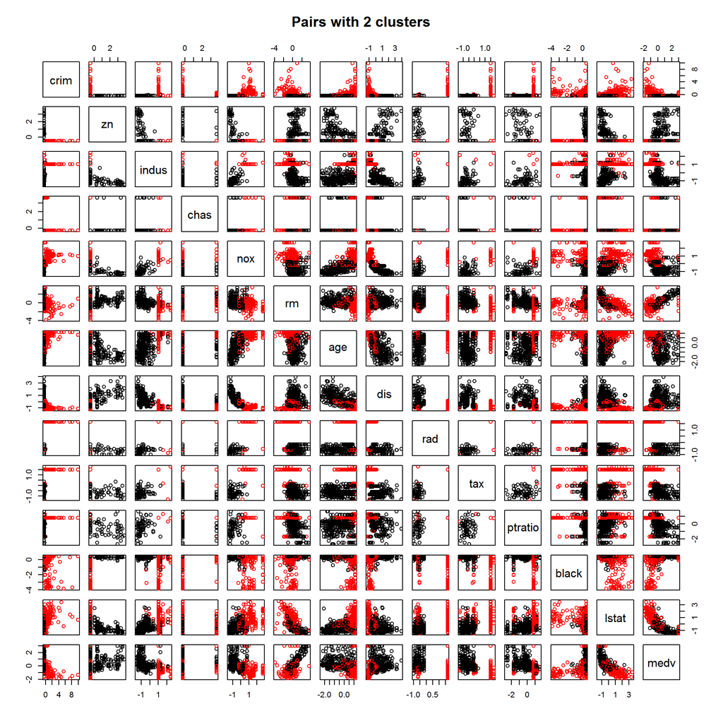

```r
library(dygraphs)


km_eu <- kmeans(dist_eu, centers = 2)
pairs(reboston_scaled, col = km_eu$cluster, main = "Pairs with 2 clusters")
```

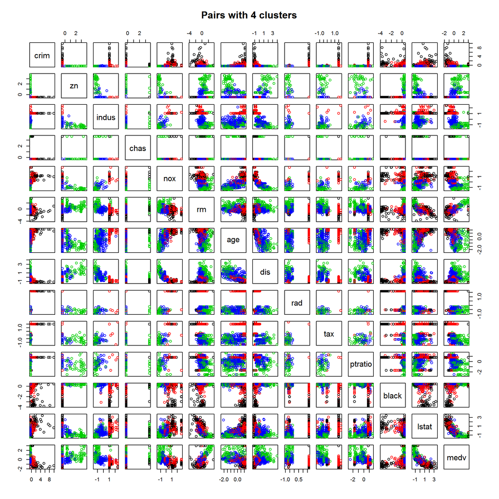

```r
km_eu2 <- kmeans(dist_eu, centers = 4)
pairs(reboston_scaled, col = km_eu2$cluster, main = "Pairs with 4 clusters")
```

**DETERMINING THE NUMBER OF CLUSTERS**

Here the purpose is to find the optimal number of clusters. Idea behind the K-means clustering is that a good clustering is one for which the within-cluster variation is as small as possible. There are different methods to achieve this goal and I’m going to use total within sum of squares, WCSS, which can be calculated with a use of formula below:

$WCSS = \sum_i^N (x_i - centroid)^2$

The formula below is adopted from the DataCamp exercises as such. The task is to found an appropriate amount of clusters. The DC guidelines adviced to choose that number of clusters where the total WCSS drops radically. So if you look at the figure below, the most radical drop happens after the first number suggestings that the optimal amount could be 2 clusters.

On the other hand the statistical textbooks (e.g. http://www-bcf.usc.edu/~gareth/ISL/ISLR%20First%20Printing.pdf) suggest that the clustering “results” may be optimal when the within-cluster variation is as small as possible.

I thought I could somehow combine the above advices and this is what I concluded: The second “cluster point” doens’t reflect the smallest variation even though there is a radical change after first “point. It seems that there are some drops between the second and sixth”point“, but between the fifth and sixth the within-cluster variation doesn’t seem be to be so different anymore. After this you may already guess that I’m suggesting 5 clusters. But I wouldn’t say that this has to be a final decision without using other tools and methods.

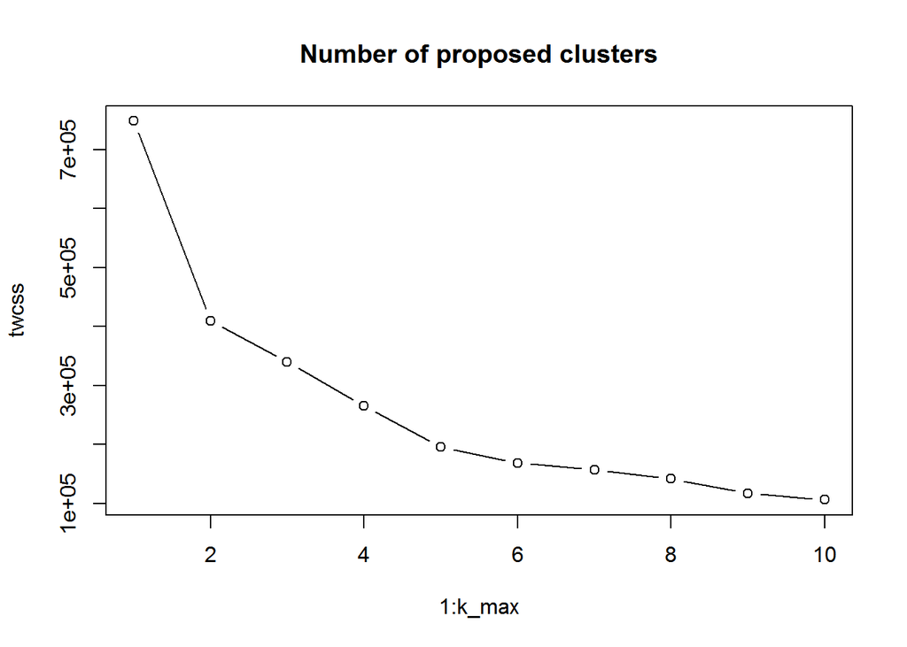

```r
set.seed(123) # keeping the results same
k_max <- 10 # maximum number of clusters
twcss <- sapply(1:k_max, function(k){kmeans(dist_eu, k)$tot.withinss})
plot(1:k_max, twcss, type='b', main = "Number of proposed clusters")
```

**USING THE ELBOW METHOD TO DETERMINE THE NUMBER OF CLUSTERS**

Then there is a so called Elbow Method which also uses the within-cluster variance. You can adopt the method and algorith [here](http://www.sthda.com/english/wiki/determining-the-optimal-number-of-clusters-3-must-known-methods-unsupervised-machine-learning). In this site the author suggest that “the location of a bend (knee) in the plot is generally considered as an indicator of the appropriate number of clusters”.

Below you can perceive two plots with the Elbow method. I have to say that I’m not sure anymore what could be the “correct” number of clusters. Here I would rather say 2 than 5. Note that I draw the dashed lines just to compare the results.

But I’m not happy yet with the results. So let’s take a look at one more method after this.

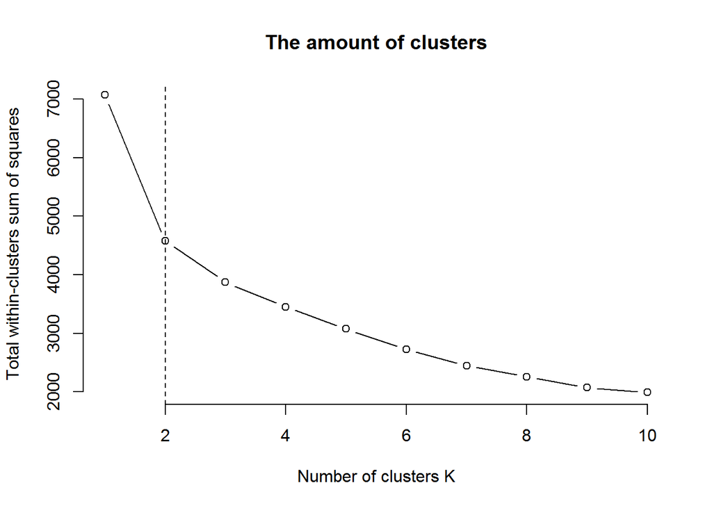

```r
set.seed(123)

# Computing and plotting wss for k = 2 to k = 10
k.max <- 10 # Maximal number of clusters
data <- reboston_scaled
wss <- sapply(1:k.max,
        function(k){kmeans(data, k, nstart=10 )$tot.withinss})
plot(1:k.max, wss,
       type="b", pch = 1, frame = FALSE,
       xlab="Number of clusters K",
       ylab="Total within-clusters sum of squares", main = "The amount of clusters")
abline(v = 2, lty =2)
```

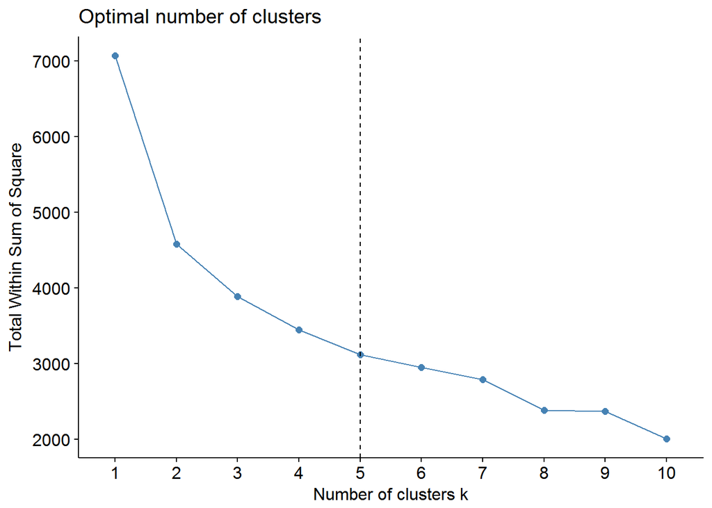

```r
# Another functions, same method
library(factoextra); require(ggplot2)
fviz_nbclust(reboston_scaled, kmeans, method = "wss") +
  geom_vline(xintercept = 5, linetype = 2)
```

**USING THE “ALL VALIDATION INDICES” TO DETERMINE THE NUMBER OF CLUSTERS**

This method is also adopted from the website I introduced above. This might be “heavy” method when it computes all the 30 indices for determining the optimal number of clusters (see ?NbClust for additional information). Note that the command “all” actually drops some indices for the sake of faster computing.

**So according to this method of majority rule, the best number of clusters is 2.**

```r
library(NbClust)

nb <- NbClust(reboston_scaled, distance = "euclidean", min.nc = 2,
        max.nc = 10, method = "complete", index ="all")
```

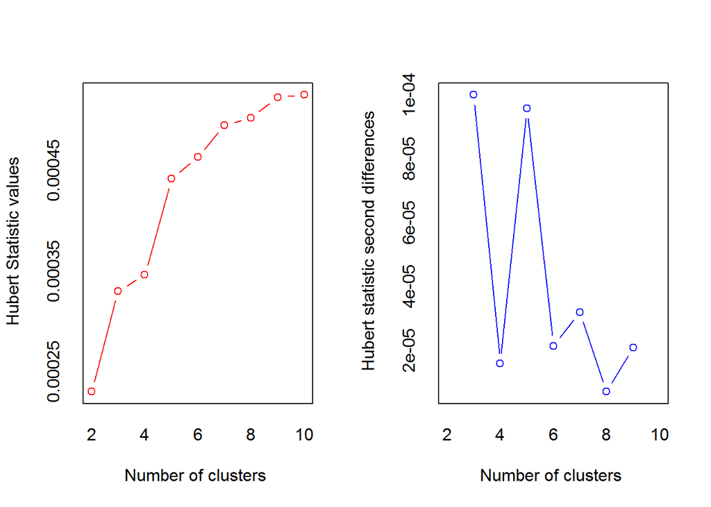

```
## *** : The Hubert index is a graphical method of determining the number of clusters.
##                 In the plot of Hubert index, we seek a significant knee that corresponds to a
##                 significant increase of the value of the measure i.e the significant peak in Hubert
##                 index second differences plot.
##
```

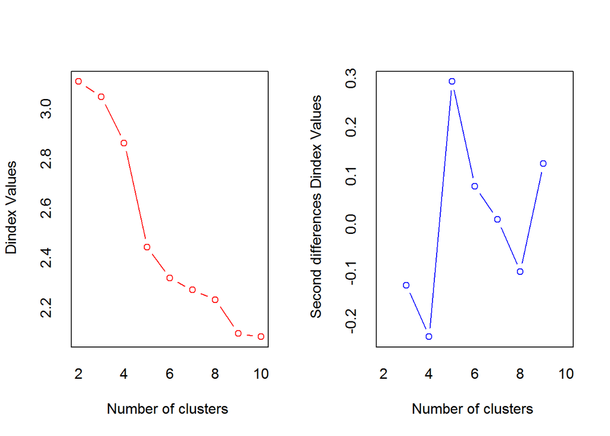

```
## *** : The D index is a graphical method of determining the number of clusters.
##                 In the plot of D index, we seek a significant knee (the significant peak in Dindex
##                 second differences plot) that corresponds to a significant increase of the value of
##                 the measure.
##
## * Among all indices:
## * 9 proposed 2 as the best number of clusters
## * 1 proposed 3 as the best number of clusters
## * 6 proposed 5 as the best number of clusters
## * 1 proposed 6 as the best number of clusters
## * 2 proposed 9 as the best number of clusters
## * 4 proposed 10 as the best number of clusters
##
##                    ***** Conclusion *****
##
## * According to the majority rule, the best number of clusters is  2
##
##
```

```r
nb
```

```
## $All.index
##          KL       CH Hartigan      CCC    Scott      Marriot    TrCovW
## 2  365.8858 138.3799  30.2810 -10.6105  546.752 3.282035e+33 379348.85
## 3    0.0051  88.3119  68.0689 -16.2831 1135.949 2.304751e+33 344603.04
## 4    0.4190  89.3535 157.2726 -14.9359 1713.232 1.309260e+33 251173.09
## 5    3.3113 127.0749  59.2562  -0.9093 2860.839 2.117710e+32 120863.36
## 6    4.9882 125.2845  20.4741   3.8642 3531.911 8.095706e+31  97956.82
## 7    0.6595 111.8671  24.1067   4.0150 3820.466 6.229953e+31  89795.14
## 8    0.2506 103.7538  73.4329   5.0250 4307.836 3.105734e+31  85970.73
## 9  121.0692 113.1228   7.0030  13.6910 4924.178 1.162705e+31  59638.61
## 10   0.1218 102.5418  11.2077  12.4447 5033.461 1.156612e+31  58526.58
##      TraceW Friedman  Rubin Cindex     DB Silhouette   Duda Pseudot2
## 2  5546.998  11.6512 1.2746 0.3501 1.8755     0.1927 0.9033  32.2200
## 3  5232.616  15.3777 1.3511 0.4039 1.5318     0.1870 0.7283  74.9817
## 4  4608.911  20.8047 1.5340 0.4425 1.6959     0.1720 0.6174 182.7857
```

[output cut: 115 more lines]

```
## Among all indices:
## ===================
## * 2 proposed  0 as the best number of clusters
## * 1 proposed  1 as the best number of clusters
## * 9 proposed  2 as the best number of clusters
## * 1 proposed  3 as the best number of clusters
## * 6 proposed  5 as the best number of clusters
## * 1 proposed  6 as the best number of clusters
## * 2 proposed  9 as the best number of clusters
## * 4 proposed  10 as the best number of clusters
##
## Conclusion
## =========================
## * According to the majority rule, the best number of clusters is  2 .
```

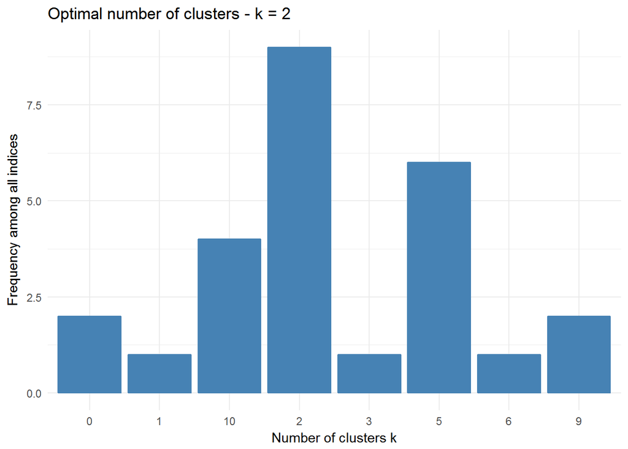

```r
# Visualizing the results
fviz_nbclust(nb) + theme_minimal()
```

Here you can look again the pair matrix of two clusters.

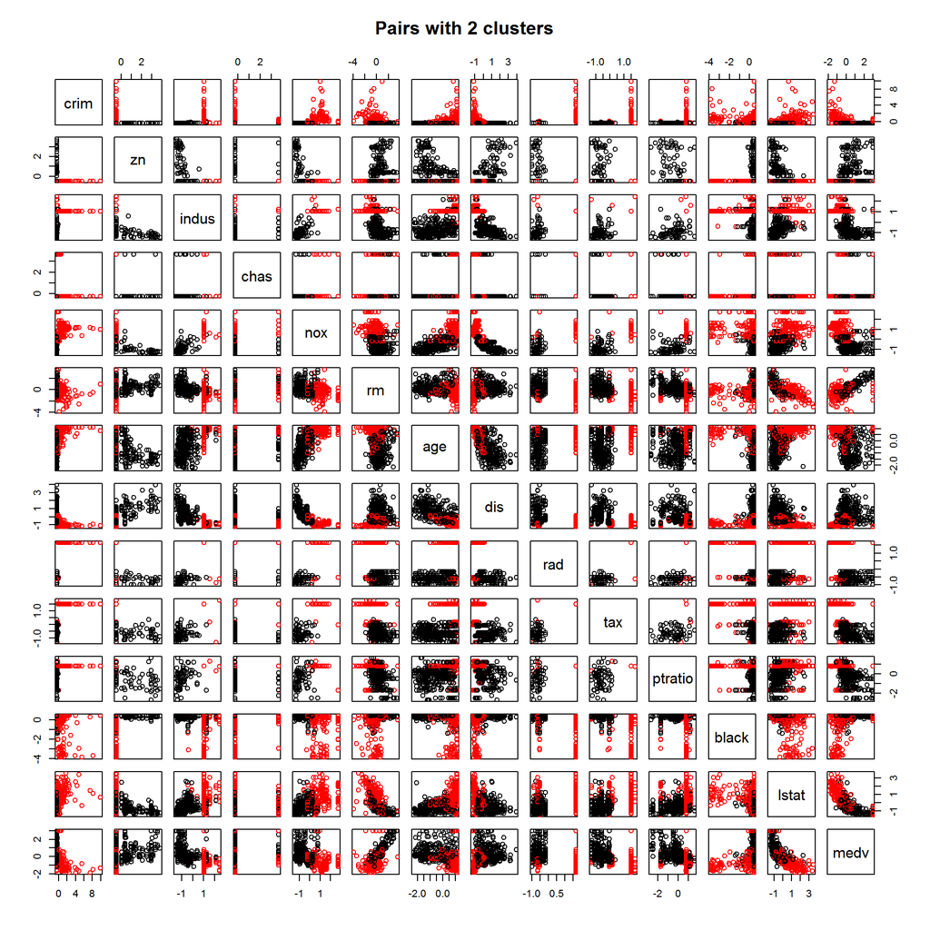

```r
# Lets plot the pairs with two centers again

library(dygraphs)

pairs(reboston_scaled, col = km_eu$cluster, main = "Pairs with 2 clusters")
```